# 2016 Nebraska Presidential Contributions

# Some Tentative Questions (Not Phrased As Questions)

Let’s look at 2016 presidential contributions from my home state of Nebraska. The population of people we’re looking at is Nebraskan’s who contributed to a presidential candidate during the primaries or the general election. I’m curious about: * the number of Democrat and Republican contributors * the location of the contributors * the probable gender of the contributors * the occupations of the contributors * the amount contributed by candidate, location, date, and gender * the candidates receiving contributions

# The Data

I got an error about duplicate row names and resolved it with some guidance from the [forums](https://discussions.udacity.com/t/p4-load-csv-issue/29971/3). Apparently, someone added a superfluous comma - probably an overzealous [Oxford](https://www.grammarly.com/blog/what-is-the-oxford-comma-and-why-do-people-care-so-much-about-it/) enthusiast. So I added a dummy column, then removed it. It’s a bit of a mystery why the contributor state column is included when the dataset by definition only includes Nebraska contributors. In fact, let’s just remove it because a variable that has the same value for the entire dataset offends me.

```r
contbr = read.csv('C:\\Users\\Nathan\\Desktop\\p4_EDA\\ne_data.csv')
contbr = subset(contbr, select = -c(X, contbr_st))
str(contbr)
```

```
'data.frame':   27683 obs. of  17 variables:
 $ cmte_id          : Factor w/ 22 levels "C00458844","C00500587",..: 14 14 14 6 14 6 7 6 6 11 ...
 $ cand_id          : Factor w/ 22 levels "P00003392","P20002671",..: 21 21 21 1 21 1 12 1 1 14 ...
 $ cand_nm          : Factor w/ 22 levels "Bush, Jeb","Carson, Benjamin S.",..: 21 21 21 4 21 4 18 4 4 14 ...
 $ contbr_nm        : Factor w/ 7403 levels "'CALLAHAN, MICHAEL",..: 5267 5267 5267 6360 6224 691 4569 3370 3019 985 ...
 $ contbr_city      : Factor w/ 515 levels " SAINT EDWARD",..: 348 348 348 348 215 348 269 269 348 348 ...
 $ contbr_zip       : Factor w/ 3778 levels "","0","10027",..: 1041 1041 1041 789 1861 1717 2237 2249 462 452 ...
 $ contbr_employer  : Factor w/ 2228 levels "","- SELECT -",..: 1662 1662 1662 879 1758 1758 2037 1662 1161 325 ...
 $ contbr_occupation: Factor w/ 1695 levels "","911 DISPATCHER",..: 1328 1328 1328 1061 971 1047 998 1540 1424 106 ...
 $ contb_receipt_amt: num  -80 -80 -80 77.5 124.8 ...
 $ contb_receipt_dt : Factor w/ 621 levels "01-APR-15","01-APR-16",..: 122 262 400 506 481 206 116 86 527 613 ...
 $ receipt_desc     : Factor w/ 10 levels "","REATTRIBUTION / REDESIGNATION REQUESTED",..: 1 1 1 1 1 1 1 1 1 1 ...
 $ memo_cd          : Factor w/ 2 levels "","X": 2 2 2 2 2 2 1 2 2 1 ...
 $ memo_text        : Factor w/ 26 levels "","$0.72 REFUNDED ON 10/25/2016",..: 1 1 1 6 1 6 3 6 6 3 ...
 $ form_tp          : Factor w/ 3 levels "SA17A","SA18",..: 2 2 2 2 2 2 1 2 2 1 ...
 $ file_num         : int  1146165 1146165 1146165 1091718 1146165 1091718 1077404 1091718 1091718 1144666 ...
 $ tran_id          : Factor w/ 27639 levels "A009F9A20369B4F0E852",..: 19041 19042 19043 7317 21035 7288 23450 7276 7320 27638 ...
 $ election_tp      : Factor w/ 4 levels "","G2016","O2016",..: 2 2 2 4 2 4 4 4 4 4 ...
```

Let’s view a numeric summary.

```r
summary(contbr)
```

```
      cmte_id           cand_id                           cand_nm
 C00575795:10377   P00003392:10377   Clinton, Hillary Rodham  :10377
 C00577130: 6542   P60007168: 6542   Sanders, Bernard         : 6542
 C00580100: 4838   P80001571: 4838   Trump, Donald J.         : 4838
 C00574624: 2610   P60006111: 2610   Cruz, Rafael Edward 'Ted': 2610
 C00573519: 2383   P60005915: 2383   Carson, Benjamin S.      : 2383
 C00458844:  324   P60006723:  324   Rubio, Marco             :  324
 (Other)  :  609   (Other)  :  609   (Other)                  :  609
                contbr_nm        contbr_city       contbr_zip                 contbr_employer
 ORTEGA, ELIZABETH   :  165   OMAHA    :9227   681062249:  165   RETIRED              : 4468
 MYERS, PAT C.       :  117   LINCOLN  :6510   68516    :  155   N/A                  : 3242
 MORRISSEY, CATHERINE:  107   BELLEVUE :1063   68154    :  153   SELF-EMPLOYED        : 1818
 DEANE, MARY         :   99   PAPILLION: 604   68114    :  128   INFORMATION REQUESTED: 1423
 PETERSON, SANDRA    :   92   ELKHORN  : 428   68130    :  127   NONE                 : 1168
 DUDDEN, CONNIE      :   87   KEARNEY  : 419   68137    :  126   (Other)              :15540
 (Other)             :27016   (Other)  :9432   (Other)  :26829   NA's                 :   24
             contbr_occupation contb_receipt_amt   contb_receipt_dt
 RETIRED              : 6662   Min.   :-4600.00   11-JUL-16:  418
 NOT EMPLOYED         : 1626   1st Qu.:   19.00   12-JUL-16:  408
 INFORMATION REQUESTED: 1409   Median :   28.00   06-JUL-16:  381
 PROFESSOR            :  637   Mean   :   88.44   29-FEB-16:  281
 ATTORNEY             :  551   3rd Qu.:   80.00   31-MAR-16:  248
 (Other)              :16779   Max.   : 5400.00   10-AUG-16:  237
 NA's                 :   19                      (Other)  :25710
                                  receipt_desc   memo_cd
                                        :27476    :21581
 Refund                                 :  137   X: 6102
 REDESIGNATION FROM PRIMARY             :   22
 REDESIGNATION TO GENERAL               :   22
 REATTRIBUTION / REDESIGNATION REQUESTED:    7
 REATTRIBUTION FROM SPOUSE              :    5
 (Other)                                :   14
                               memo_text      form_tp         file_num            tran_id
                                    :19195   SA17A:21546   Min.   :1003942   C10291700:    2
 * EARMARKED CONTRIBUTION: SEE BELOW: 6367   SA18 : 6000   1st Qu.:1077648   C10292957:    2
 * HILLARY VICTORY FUND             : 1959   SB28A:  137   Median :1096305   C10296509:    2
 EARMARKED FROM MAKE DC LISTEN      :   37                 Mean   :1099758   C10474463:    2
 *BEST EFFORTS UPDATE               :   26                 3rd Qu.:1133832   C11767943:    2
 REDESIGNATION FROM PRIMARY         :   22                 Max.   :1146285   C11773347:    2
 (Other)                            :   77                                   (Other)  :27671
 election_tp
      :  100
 G2016: 8994
 O2016:    2
 P2016:18587
```

# Contributions

## How much did people contribute?

```r
summary(contbr$contb_receipt_amt)
```

```
    Min.  1st Qu.   Median     Mean  3rd Qu.     Max.
-4600.00    19.00    28.00    88.44    80.00  5400.00
```

That maximum makes sense because the presidential campaign had two separate elections, the primary and the general election, and the maximum contribution amount for an individual is [$2,700](http://www.fec.gov/pages/brochures/citizens.shtml#how_much). It’s a bit of a mystery why some individuals appear to be getting credited from campaign committees and I didn’t find an explanation with a cursory keyword search.

Looking at these quartiles though, we have some outliers. Let’s get counts, then eliminate them for visualization.

```r
contbr$contb_amt_quartiles <- cut(contbr$contb_receipt_amt,
                                  breaks = c(-4600, 19, 28, 80, 5400))
table(contbr$contb_amt_quartiles)
```

```
(-4.6e+03,19]       (19,28]       (28,80]  (80,5.4e+03]
         7230          6806          7116          6530
```

Now that I finished this, I realize I didn’t accomplish what I was trying to accomplish. I merely counted the amount of observations in each quartile. What I want to do is eliminate the [top and bottom 1%](http://r.789695.n4.nabble.com/removing-lower-and-upper-quantiles-from-an-arry-td3310479.html) of values.

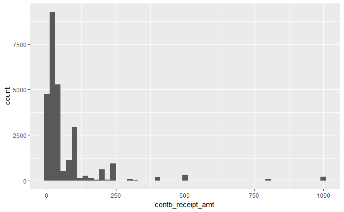

```r
library(ggplot2)
ggplot(aes(x = contb_receipt_amt),
       data = contbr[contbr$contb_receipt_amt >= quantile(contbr$contb_receipt_amt, .01) &
         contbr$contb_receipt_amt <= quantile(contbr$contb_receipt_amt, .99), ]) +
  geom_histogram(binwidth = 20)
```

I’ve heard from past reading and news consumption that since Barack Obama’s 2008 campaign, campaigns have seen a large uptick in the number of small individual contributions. In this case, most are below $250. Let’s take a closer look at the contributions less than $250.

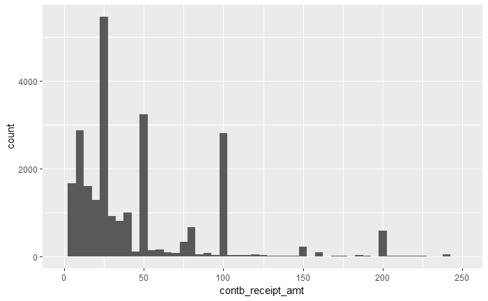

```r
ggplot(aes(x = contb_receipt_amt),
       data = contbr) +
  geom_histogram(binwidth = 5) +
  xlim(-1, 250)
```

So, small amounts and easy denominations are popular, such as $25, $50, and $100. What about if we look at less than $100 contributions?

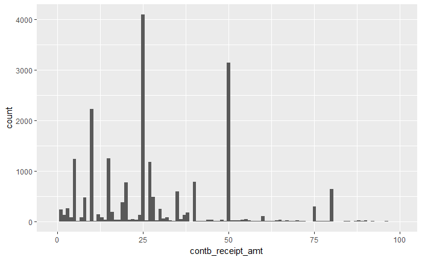

```r
ggplot(aes(x = contb_receipt_amt),
       data = contbr) +
  geom_histogram(binwidth = 1) +
  xlim(-1, 100)
```

And this looks like further confirmation for the tendency to use easy denominations with multiples of 5, like $5, $10, $15, etc.

## Where did contributions originate?

```r
summary(contbr$contbr_city, maxsum = 10)
```

```
       OMAHA      LINCOLN     BELLEVUE    PAPILLION      ELKHORN      KEARNEY GRAND ISLAND
        9227         6510         1063          604          428          419          407
NORTH PLATTE      FREMONT      (Other)
         356          317         8352
```

```r
(9227+6510)/nrow(contbr)
```

```
[1] 0.5684716
```

Omaha and Lincoln have the highest population densities and are the most ethnically diverse. They account for about 57% of the contributions. I saw earlier that Clinton and Sanders received a lot of contributions so if maybe the majority of contributions were to the two Democrats.

## Who received contributions?

```r
summary(contbr$cand_nm, maxsum = 6)
```

```
  Clinton, Hillary Rodham          Sanders, Bernard          Trump, Donald J.
                    10377                      6542                      4838
Cruz, Rafael Edward 'Ted'       Carson, Benjamin S.                   (Other)
                     2610                      2383                       933
```

```r
(10477+6542)/nrow(contbr)
```

```
[1] 0.6147816
```

60% of contributions went to Clinton or Sanders. This is a surprise.

I’d speculate that Republicans were either unenthusiastic with their choices or were expecting a Republican would carry the state so not as many bothered to financially invest in a Republican candidate.

About 60% of contributions went to the campaigning Democrats (except poor [O’Malley and Lessig](https://en.wikipedia.org/wiki/United_States_presidential_election,_2016#Nominees_2) and a little under 60% of contributions originated from the metro areas. Using location as a dubious proxy for party, it appears that Nebraska Democrats were more willing to financially invest in their candidate of choice than Nebraska Republicans.

## How does gender affect contributions?

Abort! I don’t see a quick or approximate way of classifying people by gender with this data. I considered using an outside list of designated male and female names to classify the names in this dataset. However, that seems like more work than is warranted for a mildly interesting question that is likely not important.

## What are the jobs of most contributors?

```r
summary(contbr$contbr_occupation, maxsum = 10)
```

```
              RETIRED          NOT EMPLOYED INFORMATION REQUESTED             PROFESSOR
                 6662                  1626                  1409                   637
             ATTORNEY             HOMEMAKER               TEACHER                FARMER
                  551                   548                   453                   341
              (Other)                  NA's
                15437                    19
```

This “Information Requested” category seems like an NA proxy where the contributor didn’t respond.

## Dates of Contributions

This is actually the date on the receipt of the contribution, not the day the contribution was made. Let’s change these date factors to datetime objects for plotting. A couple questions might be interesting here. * Do we see spikes in contributions around certain dates? * Who is getting contributed to by date?

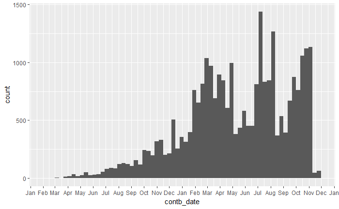

```r
contbr$contb_date <- as.Date(contbr$contb_receipt_dt, format = "%d-%b-%y")
ggplot(aes(x = contb_date), data = contbr) +
  geom_histogram(binwidth = 10) +
  scale_x_date(date_breaks = '1 month', date_labels = "%b",
               limits = c(as.Date('2015-02-01'), as.Date('2016-12-01')))
```

Needed to lookup how to limit the [display of dates](https://stackoverflow.com/questions/14759676/specification-of-first-and-last-tick-marks-with-ggplot2-with-scale-x-date).

This is interesting. There’s a heavy sustained period of contributions made from about January to May of 2016. Later, we observe a spike in contributions in July and August. Then a final round of contributions in the last days of the general election in October and November.

I would think that fundraising is much more important at the start of the primary season and the start of the general election. We observe the latter occurring in response to the [Republican](https://en.wikipedia.org/wiki/2016_Republican_National_Convention) and [Democratic](https://en.wikipedia.org/wiki/2016_Democratic_National_Convention) conventions, but not the former. Probably because it’s difficult to get people engaged 18-20 months ahead of the election.

Let’s take a closer look at contributions around convention time to see if my intuition is correct.

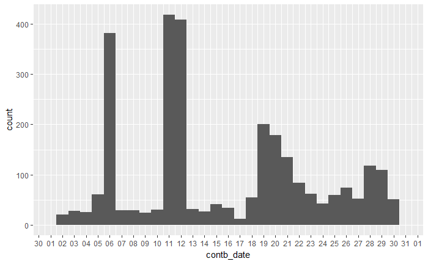

```r
ggplot(aes(x = contb_date), data = contbr) +
  geom_histogram(binwidth = 1) +
  scale_x_date(date_breaks = '1 day', date_labels = "%d",
               limits = c(as.Date('2016-07-01'), as.Date('2016-07-31')))
```

The dates aren’t quite matching up. The conventions started on the 18th and 25th. This makes me think that contributors responded to the *announcements* of the expected winners by news media rather than the official party selections of their candidates. This would be tougher to support with data since there’s no official announcement. I doubt even the politically engaged were following closely enough to know when their preferred candidate was mathematically eliminated from receiving enough primary votes. The hypothesis makes intuitive sense though. We do observe increases in contributions around each of the conventions.

## Who is getting contributed to by date?